# W3cubDocs

/Matplotlib 3.5

# matplotlib.axes.Axes.annotate

**Axes.annotate(*text*, *xy*, *args, **kwargs)[[source]](https://github.com/matplotlib/matplotlib/blob/v3.5.1/lib/matplotlib/axes/_axes.py#L664-L671)**

Annotate the point *xy* with text *text*.

In the simplest form, the text is placed at *xy*.

Optionally, the text can be displayed in another position *xytext*. An arrow pointing from the text to the annotated point *xy* can then be added by defining *arrowprops*.

**Parameters**

**text**str**

The text of the annotation.

**xy**(float, float)**

The point *(x, y)* to annotate. The coordinate system is determined by *xycoords*.

**xytext**(float, float), default: *xy**

The position *(x, y)* to place the text at. The coordinate system is determined by *textcoords*.

**xycoords**str or `Artist` or `Transform` or callable or (float, float), default: 'data'**

The coordinate system that *xy* is given in. The following types of values are supported:

- One of the following strings:

  | Value | Description |
  | --- | --- |
  | 'figure points' | Points from the lower left of the figure |
  | 'figure pixels' | Pixels from the lower left of the figure |
  | 'figure fraction' | Fraction of figure from lower left |
  | 'subfigure points' | Points from the lower left of the subfigure |
  | 'subfigure pixels' | Pixels from the lower left of the subfigure |
  | 'subfigure fraction' | Fraction of subfigure from lower left |
  | 'axes points' | Points from lower left corner of axes |
  | 'axes pixels' | Pixels from lower left corner of axes |
  | 'axes fraction' | Fraction of axes from lower left |
  | 'data' | Use the coordinate system of the object being annotated (default) |
  | 'polar' | *(theta, r)* if not native 'data' coordinates |

  Note that 'subfigure pixels' and 'figure pixels' are the same for the parent figure, so users who want code that is usable in a subfigure can use 'subfigure pixels'.
- An `Artist`: *xy* is interpreted as a fraction of the artist's `Bbox`. E.g. *(0, 0)* would be the lower left corner of the bounding box and *(0.5, 1)* would be the center top of the bounding box.
- A `Transform` to transform *xy* to screen coordinates.
- A function with one of the following signatures:

  ```
  def transform(renderer) -> Bbox
  def transform(renderer) -> Transform
  ```

  where *renderer* is a `RendererBase` subclass.

  The result of the function is interpreted like the `Artist` and `Transform` cases above.
- A tuple *(xcoords, ycoords)* specifying separate coordinate systems for *x* and *y*. *xcoords* and *ycoords* must each be of one of the above described types.

See [Advanced Annotations](https://matplotlib.org/3.5.1/tutorials/text/annotations.html#plotting-guide-annotation) for more details.

**textcoords**str or `Artist` or `Transform` or callable or (float, float), default: value of *xycoords**

The coordinate system that *xytext* is given in.

All *xycoords* values are valid as well as the following strings:

| Value | Description |
| --- | --- |
| 'offset points' | Offset (in points) from the *xy* value |
| 'offset pixels' | Offset (in pixels) from the *xy* value |

**arrowprops**dict, optional**

The properties used to draw a `FancyArrowPatch` arrow between the positions *xy* and *xytext*. Defaults to None, i.e. no arrow is drawn.

For historical reasons there are two different ways to specify arrows, "simple" and "fancy":

**Simple arrow:**

If *arrowprops* does not contain the key 'arrowstyle' the allowed keys are:

| Key | Description |
| --- | --- |
| width | The width of the arrow in points |
| headwidth | The width of the base of the arrow head in points |
| headlength | The length of the arrow head in points |
| shrink | Fraction of total length to shrink from both ends |
| ? | Any key to `matplotlib.patches.FancyArrowPatch` |

The arrow is attached to the edge of the text box, the exact position (corners or centers) depending on where it's pointing to.

**Fancy arrow:**

This is used if 'arrowstyle' is provided in the *arrowprops*.

Valid keys are the following `FancyArrowPatch` parameters:

| Key | Description |
| --- | --- |
| arrowstyle | the arrow style |
| connectionstyle | the connection style |
| relpos | see below; default is (0.5, 0.5) |
| patchA | default is bounding box of the text |
| patchB | default is None |
| shrinkA | default is 2 points |
| shrinkB | default is 2 points |
| mutation_scale | default is text size (in points) |
| mutation_aspect | default is 1. |
| ? | any key for `matplotlib.patches.PathPatch` |

The exact starting point position of the arrow is defined by *relpos*. It's a tuple of relative coordinates of the text box, where (0, 0) is the lower left corner and (1, 1) is the upper right corner. Values <0 and >1 are supported and specify points outside the text box. By default (0.5, 0.5) the starting point is centered in the text box.

**annotation_clip**bool or None, default: None**

Whether to draw the annotation when the annotation point *xy* is outside the axes area.

- If *True*, the annotation will only be drawn when *xy* is within the axes.
- If *False*, the annotation will always be drawn.
- If *None*, the annotation will only be drawn when *xy* is within the axes and *xycoords* is 'data'.

**kwargs**

Additional kwargs are passed to `Text`.

**Returns**

**`Annotation`**

See also

**[Advanced Annotations](https://matplotlib.org/3.5.1/tutorials/text/annotations.html#plotting-guide-annotation)**

## Examples using `matplotlib.axes.Axes.annotate`

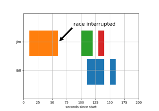

[Broken Barh](https://matplotlib.org/3.5.1/gallery/lines_bars_and_markers/broken_barh.html#sphx-glr-gallery-lines-bars-and-markers-broken-barh-py)

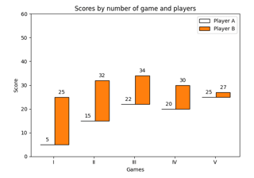

[Hat graph](https://matplotlib.org/3.5.1/gallery/lines_bars_and_markers/hat_graph.html#sphx-glr-gallery-lines-bars-and-markers-hat-graph-py)

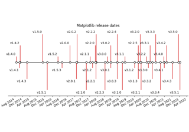

[Creating a timeline with lines, dates, and text](https://matplotlib.org/3.5.1/gallery/lines_bars_and_markers/timeline.html#sphx-glr-gallery-lines-bars-and-markers-timeline-py)

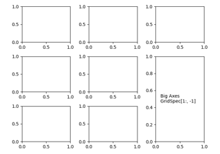

[Combining two subplots using subplots and GridSpec](https://matplotlib.org/3.5.1/gallery/subplots_axes_and_figures/gridspec_and_subplots.html#sphx-glr-gallery-subplots-axes-and-figures-gridspec-and-subplots-py)

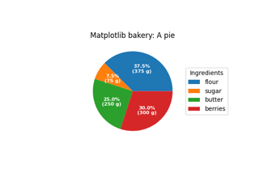

[Labeling a pie and a donut](https://matplotlib.org/3.5.1/gallery/pie_and_polar_charts/pie_and_donut_labels.html#sphx-glr-gallery-pie-and-polar-charts-pie-and-donut-labels-py)

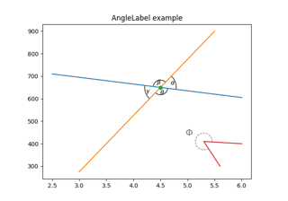

[Scale invariant angle label](https://matplotlib.org/3.5.1/gallery/text_labels_and_annotations/angle_annotation.html#sphx-glr-gallery-text-labels-and-annotations-angle-annotation-py)

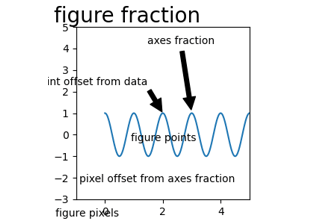

[Annotating Plots](https://matplotlib.org/3.5.1/gallery/text_labels_and_annotations/annotation_demo.html#sphx-glr-gallery-text-labels-and-annotations-annotation-demo-py)

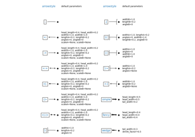

[Annotation arrow style reference](https://matplotlib.org/3.5.1/gallery/text_labels_and_annotations/fancyarrow_demo.html#sphx-glr-gallery-text-labels-and-annotations-fancyarrow-demo-py)

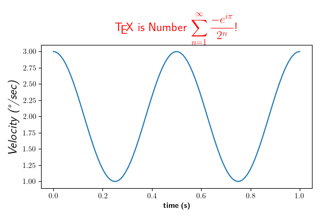

[Rendering math equations using TeX](https://matplotlib.org/3.5.1/gallery/text_labels_and_annotations/tex_demo.html#sphx-glr-gallery-text-labels-and-annotations-tex-demo-py)

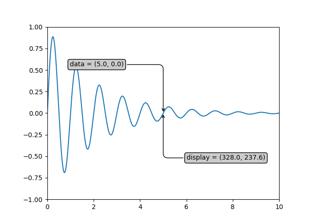

[Annotate Transform](https://matplotlib.org/3.5.1/gallery/pyplots/annotate_transform.html#sphx-glr-gallery-pyplots-annotate-transform-py)

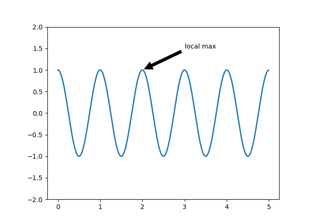

[Annotating a plot](https://matplotlib.org/3.5.1/gallery/pyplots/annotation_basic.html#sphx-glr-gallery-pyplots-annotation-basic-py)

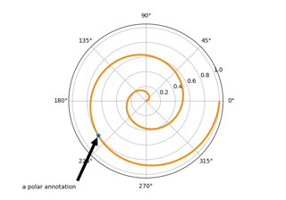

[Annotation Polar](https://matplotlib.org/3.5.1/gallery/pyplots/annotation_polar.html#sphx-glr-gallery-pyplots-annotation-polar-py)

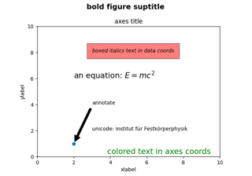

[Text Commands](https://matplotlib.org/3.5.1/gallery/pyplots/text_commands.html#sphx-glr-gallery-pyplots-text-commands-py)

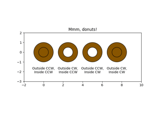

[Mmh Donuts!!!](https://matplotlib.org/3.5.1/gallery/shapes_and_collections/donut.html#sphx-glr-gallery-shapes-and-collections-donut-py)

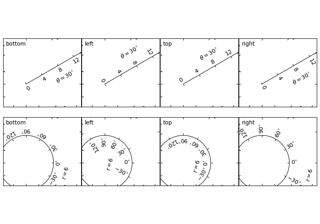

[axis_direction demo](https://matplotlib.org/3.5.1/gallery/axisartist/demo_axis_direction.html#sphx-glr-gallery-axisartist-demo-axis-direction-py)

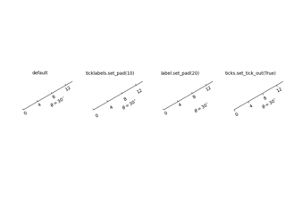

[Simple Axis Pad](https://matplotlib.org/3.5.1/gallery/axisartist/simple_axis_pad.html#sphx-glr-gallery-axisartist-simple-axis-pad-py)

[figure not shown]

[XKCD](https://matplotlib.org/3.5.1/gallery/showcase/xkcd.html#sphx-glr-gallery-showcase-xkcd-py)

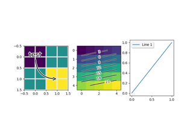

[Patheffect Demo](https://matplotlib.org/3.5.1/gallery/misc/patheffect_demo.html#sphx-glr-gallery-misc-patheffect-demo-py)

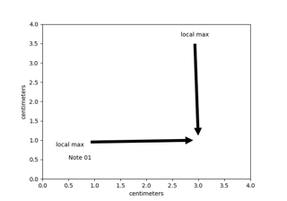

[Annotation with units](https://matplotlib.org/3.5.1/gallery/units/annotate_with_units.html#sphx-glr-gallery-units-annotate-with-units-py)

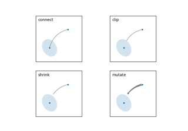

[Annotate Explain](https://matplotlib.org/3.5.1/gallery/userdemo/annotate_explain.html#sphx-glr-gallery-userdemo-annotate-explain-py)

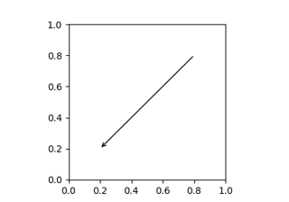

[Annotate Simple01](https://matplotlib.org/3.5.1/gallery/userdemo/annotate_simple01.html#sphx-glr-gallery-userdemo-annotate-simple01-py)

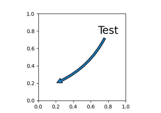

[Annotate Simple02](https://matplotlib.org/3.5.1/gallery/userdemo/annotate_simple02.html#sphx-glr-gallery-userdemo-annotate-simple02-py)

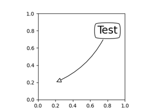

[Annotate Simple03](https://matplotlib.org/3.5.1/gallery/userdemo/annotate_simple03.html#sphx-glr-gallery-userdemo-annotate-simple03-py)

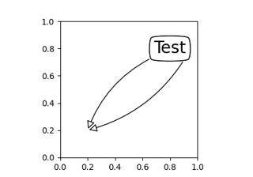

[Annotate Simple04](https://matplotlib.org/3.5.1/gallery/userdemo/annotate_simple04.html#sphx-glr-gallery-userdemo-annotate-simple04-py)

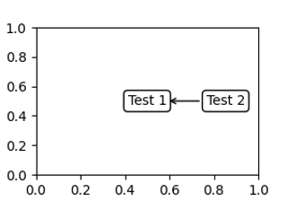

[Annotate Simple Coord01](https://matplotlib.org/3.5.1/gallery/userdemo/annotate_simple_coord01.html#sphx-glr-gallery-userdemo-annotate-simple-coord01-py)

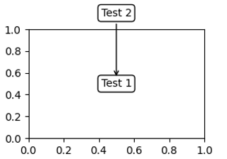

[Annotate Simple Coord02](https://matplotlib.org/3.5.1/gallery/userdemo/annotate_simple_coord02.html#sphx-glr-gallery-userdemo-annotate-simple-coord02-py)

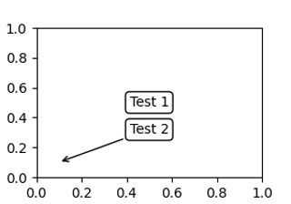

[Annotate Simple Coord03](https://matplotlib.org/3.5.1/gallery/userdemo/annotate_simple_coord03.html#sphx-glr-gallery-userdemo-annotate-simple-coord03-py)

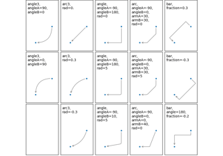

[Connection styles for annotations](https://matplotlib.org/3.5.1/gallery/userdemo/connectionstyle_demo.html#sphx-glr-gallery-userdemo-connectionstyle-demo-py)

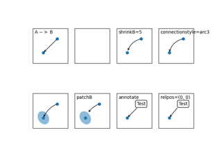

[Simple Annotate01](https://matplotlib.org/3.5.1/gallery/userdemo/simple_annotate01.html#sphx-glr-gallery-userdemo-simple-annotate01-py)

[Basic Usage](https://matplotlib.org/3.5.1/tutorials/introductory/usage.html#sphx-glr-tutorials-introductory-usage-py)

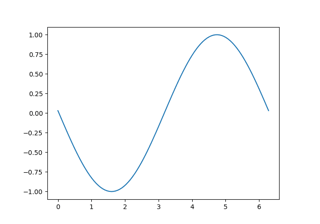

[Faster rendering by using blitting](https://matplotlib.org/3.5.1/tutorials/advanced/blitting.html#sphx-glr-tutorials-advanced-blitting-py)

[Transformations Tutorial](https://matplotlib.org/3.5.1/tutorials/advanced/transforms_tutorial.html#sphx-glr-tutorials-advanced-transforms-tutorial-py)

[Text in Matplotlib Plots](https://matplotlib.org/3.5.1/tutorials/text/text_intro.html#sphx-glr-tutorials-text-text-intro-py)

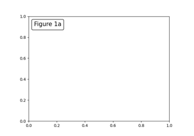

[Annotations](https://matplotlib.org/3.5.1/tutorials/text/annotations.html#sphx-glr-tutorials-text-annotations-py)